# INFSCI 2595 Fall 2021 - Final Project

Part iii: Complete problem regression – iiiB)

Jianwei Liu

2021/11/6

```r
library(tidyverse)
```

```r
library(coefplot)
library(tidymodels)
library(glmnet)
library(nnet)
library(ranger)
library(xgboost)
library(kernlab)
library(finetune)
library(kknn)
if(parallel::detectCores(logical=FALSE) > 3){
  library(doParallel)

  num_cores <- parallel::detectCores(logical=FALSE)
  cl <- makePSOCKcluster(num_cores - 1)
  registerDoParallel(cl)
}
train_v <- readr::read_csv("train_input_set_v.csv", col_names = TRUE)
train_outputs <- readr::read_csv("train_outputs.csv", col_names = TRUE)
ready_v_A <- train_v %>%
  left_join(train_outputs, by = 'run_id') %>%
  select(-run_id, -outcome)
```

### predict the continuous output with respect to the “v-variables”

#### Linear additive features

```r
set.seed(2021)
cv_folds <- vfold_cv(ready_v_A, v = 5, repeats = 5)

cv_folds
```

```
## #  5-fold cross-validation repeated 5 times
## # A tibble: 25 x 3
##    splits             id      id2
##    <list>             <chr>   <chr>
##  1 <split [1519/380]> Repeat1 Fold1
##  2 <split [1519/380]> Repeat1 Fold2
##  3 <split [1519/380]> Repeat1 Fold3
##  4 <split [1519/380]> Repeat1 Fold4
##  5 <split [1520/379]> Repeat1 Fold5
##  6 <split [1519/380]> Repeat2 Fold1
##  7 <split [1519/380]> Repeat2 Fold2
##  8 <split [1519/380]> Repeat2 Fold3
##  9 <split [1519/380]> Repeat2 Fold4
## 10 <split [1520/379]> Repeat2 Fold5
## # ... with 15 more rows
```

Define Performance metrics:

```r
my_metrics <- metric_set(rmse, rsq, mae)
```

Define linear models specification:

```r
lm_spec <- linear_reg() %>% set_engine("lm")
```

Preprocess the additive model:

```r
bp_additive <- recipe(response ~ ., data = ready_v_A) %>%
  step_center(all_predictors()) %>%
  step_scale(all_predictors())

bp_additive
```

```
## Recipe
##
## Inputs:
##
##       role #variables
##    outcome          1
##  predictor         41
##
## Operations:
##
## Centering for all_predictors()
## Scaling for all_predictors()
```

Compile the model and pre-processing into a single workflow:

```r
additive_wflow <- workflow() %>%
  add_model(lm_spec) %>%
  add_recipe(bp_additive)
```

Execute the training and testing:

```r
lm_additive_res <- additive_wflow %>%
  fit_resamples(cv_folds, metrics = my_metrics
)

lm_additive_res %>% collect_metrics()
```

```
## # A tibble: 3 x 6
##   .metric .estimator  mean     n std_err .config
##   <chr>   <chr>      <dbl> <int>   <dbl> <chr>
## 1 mae     standard   0.216    25 0.00176 Preprocessor1_Model1
## 2 rmse    standard   0.285    25 0.00270 Preprocessor1_Model1
## 3 rsq     standard   0.868    25 0.00287 Preprocessor1_Model1
```

#### All pair-wise interactions between the inputs

Follow the same procedure:

```r
bp_pairs <- bp_additive %>%
  step_interact( ~ all_predictors():all_predictors())

lm_pairs_wflow <- workflow() %>%
  add_model(lm_spec) %>%
  add_recipe(bp_pairs)

lm_pairs_res <- lm_pairs_wflow %>%
  fit_resamples(cv_folds,
                metrics = my_metrics)

lm_pairs_res %>% collect_metrics()
```

```
## # A tibble: 3 x 6
##   .metric .estimator  mean     n std_err .config
##   <chr>   <chr>      <dbl> <int>   <dbl> <chr>
## 1 mae     standard   0.260    25 0.00235 Preprocessor1_Model1
## 2 rmse    standard   0.338    25 0.00328 Preprocessor1_Model1
## 3 rsq     standard   0.829    25 0.00346 Preprocessor1_Model1
```

Add the results to the summary:

```r
all_cv_results <- lm_additive_res %>% collect_metrics(summarize = FALSE) %>%
  mutate(wflow_id = "lm_add") %>%
  bind_rows(lm_pairs_res %>% collect_metrics(summarize = FALSE) %>%
              mutate(wflow_id = "lm_pairs"))

all_cv_summaries  <- lm_additive_res %>% collect_metrics(summarize = TRUE) %>%
  mutate(wflow_id = "lm_add") %>%
  bind_rows(lm_pairs_res %>% collect_metrics(summarize = TRUE) %>%
              mutate(wflow_id = "lm_pairs"))
```

### Penalized regression - Elastic net

#### All pair-wise interactions between the inputs

First we define the search grid:

```r
my_lambda <- penalty(range = c(-10.5, 2), trans = log_trans())
my_alpha <- mixture(range = c(0.1, 1.0))
enet_grid <- grid_regular(my_lambda, my_alpha,
                          levels = c(penalty = 75, mixture = 5))

enet_grid %>% glimpse()
```

```
## Rows: 375
## Columns: 2
## $ penalty <dbl> 2.753645e-05, 3.260382e-05, 3.860371e-05, 4.570772e-05, 5.4119~
## $ mixture <dbl> 0.1, 0.1, 0.1, 0.1, 0.1, 0.1, 0.1, 0.1, 0.1, 0.1, 0.1, 0.1, 0.~
```

Then we define the elastic net model:

```r
enet_spec <- linear_reg(penalty = tune(), mixture = tune()) %>%
  set_engine("glmnet",
             # glmnet specific options
             intercept = TRUE, standardize.response = TRUE, standardize = TRUE,
             path_values = exp(seq(-10.5, 2, length.out = 75)))
```

The workflow for all pair-wise interactions is defined below:

```r
enet_pairs_wflow <- workflow() %>%
  add_model(enet_spec) %>%
  add_recipe(bp_pairs)
```

Train and test the pairs elastic net:

```r
enet_pairs_res <- tune_grid(
  enet_pairs_wflow,
  resamples = cv_folds,
  grid = enet_grid,
  metrics = my_metrics
)
```

Visualize the result:

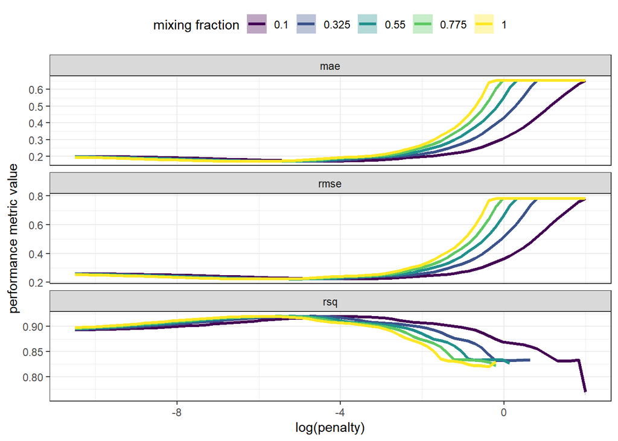

```r
enet_pairs_res %>% collect_metrics() %>%
  ggplot(mapping = aes(x = log(penalty))) +
  geom_ribbon(mapping = aes(ymin = mean - std_err,
                            ymax = mean + std_err,
                            group = interaction(mixture, .metric),
                            fill = as.factor(mixture)),
              alpha = 0.35) +
  geom_line(mapping = aes(y = mean,
                          group = interaction(mixture, .metric),
                          color = as.factor(mixture)),
            size = 1.15) +
  facet_wrap(~.metric, scales = "free_y", ncol = 1) +
  scale_fill_viridis_d("mixing fraction") +
  scale_color_viridis_d("mixing fraction") +
  labs(y = "performance metric value") +
  theme_bw() +
  theme(legend.position = "top")
```

Focus on RMSE and identify the best lambda using “1-standard error rule”:

```r
enet_pairs_res %>% select_by_one_std_err(desc(penalty), desc(mixture), metric = 'rmse')
```

```
## # A tibble: 1 x 10
##   penalty mixture .metric .estimator  mean     n std_err .config    .best .bound
##     <dbl>   <dbl> <chr>   <chr>      <dbl> <int>   <dbl> <chr>      <dbl>  <dbl>
## 1  0.0332     0.1 rmse    standard   0.224    25 0.00170 Preproces~ 0.222  0.224
```

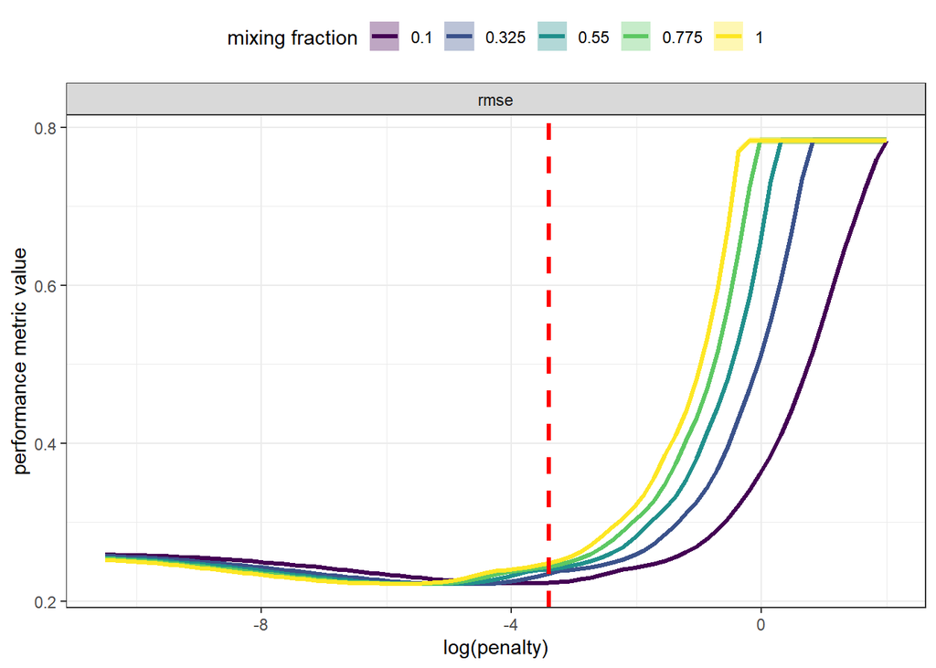

```r
enet_pairs_res %>% collect_metrics() %>%
  filter(.metric %in% c("rmse")) %>%
  ggplot(mapping = aes(x = log(penalty))) +
  geom_ribbon(mapping = aes(ymin = mean - std_err,
                            ymax = mean + std_err,
                            group = interaction(mixture, .metric),
                            fill = as.factor(mixture)),
              alpha = 0.35) +
  geom_line(mapping = aes(y = mean,
                          group = interaction(mixture, .metric),
                          color = as.factor(mixture)),
            size = 1.15) +
  geom_vline(data = enet_pairs_res %>% select_by_one_std_err(desc(penalty), desc(mixture), metric = 'rmse'),
             mapping = aes(xintercept = log(penalty)),
             color = 'red', linetype = 'dashed', size = 1.2) +
  facet_wrap(~.metric, scales = "free_y", ncol = 1) +
  scale_fill_viridis_d("mixing fraction") +
  scale_color_viridis_d("mixing fraction") +
  labs(y = 'performance metric value') +
  theme_bw() +
  theme(legend.position = "top")
```

Fit the pairs elastic net with the best tuning parameters:

```r
enet_pairs_lowest_rmse_params <- enet_pairs_res %>%
  select_by_one_std_err(desc(penalty), desc(mixture), metric = 'rmse') %>%
  select(all_of(names(enet_grid)))

final_enet_pairs_wflow <- enet_pairs_wflow %>%
  finalize_workflow(enet_pairs_lowest_rmse_params)

final_enet_pairs_fit <- final_enet_pairs_wflow %>%
  fit_resamples(cv_folds,
                metrics = my_metrics)
final_enet_pairs_fit %>% collect_metrics()
```

```
## # A tibble: 3 x 6
##   .metric .estimator  mean     n std_err .config
##   <chr>   <chr>      <dbl> <int>   <dbl> <chr>
## 1 mae     standard   0.175    25 0.00129 Preprocessor1_Model1
## 2 rmse    standard   0.224    25 0.00170 Preprocessor1_Model1
## 3 rsq     standard   0.919    25 0.00136 Preprocessor1_Model1
```

#### cubic RSM model with chosen interactions and basis features

Create the cubic RSM model with chosen interactions and basis features:

```r
bp_rsm3 <- recipe(response ~ v01 + v02 + v04 + v06 + v08 + v10 + v12, data = ready_v_A) %>%
  step_center(all_predictors()) %>%
  step_scale(all_predictors()) %>%
  step_poly(all_predictors(), degree = 3,
            options = list(raw = TRUE)) %>%
  step_interact(~ends_with("_poly_1"):ends_with("_poly_1"):ends_with("_poly_1"))

lm_rsm3_wflow <- workflow() %>%
  add_model(lm_spec) %>%
  add_recipe(bp_rsm3)

lm_rsm3_res <- lm_rsm3_wflow %>%
  fit_resamples(cv_folds,
                metrics = my_metrics)

lm_rsm3_res %>% collect_metrics()
```

```
## # A tibble: 3 x 6
##   .metric .estimator  mean     n std_err .config
##   <chr>   <chr>      <dbl> <int>   <dbl> <chr>
## 1 mae     standard   0.165    25 0.00137 Preprocessor1_Model1
## 2 rmse    standard   0.210    25 0.00158 Preprocessor1_Model1
## 3 rsq     standard   0.928    25 0.00131 Preprocessor1_Model1
```

Train and test the rsm3 elastic net:

```r
enet_rsm3_wflow <- workflow() %>%
  add_model(enet_spec) %>%
  add_recipe(bp_rsm3)

enet_rsm3_res <- tune_grid(
  enet_rsm3_wflow,
  resamples = cv_folds,
  grid = enet_grid,
  metrics = my_metrics
)
```

Visualize the result:

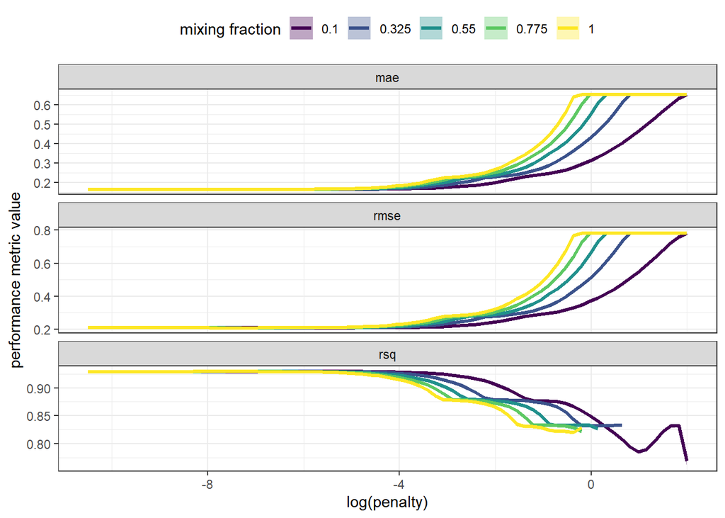

```r
enet_rsm3_res %>% collect_metrics() %>%
  ggplot(mapping = aes(x = log(penalty))) +
  geom_ribbon(mapping = aes(ymin = mean - std_err,
                            ymax = mean + std_err,
                            group = interaction(mixture, .metric),
                            fill = as.factor(mixture)),
              alpha = 0.35) +
  geom_line(mapping = aes(y = mean,
                          group = interaction(mixture, .metric),
                          color = as.factor(mixture)),
            size = 1.15) +
  facet_wrap(~.metric, scales = "free_y", ncol = 1) +
  scale_fill_viridis_d("mixing fraction") +
  scale_color_viridis_d("mixing fraction") +
  labs(y = "performance metric value") +
  theme_bw() +
  theme(legend.position = "top")
```

Focus on RMSE and identify the best lambda which minimize the RMSE:

```r
enet_rsm3_res %>% select_best(metric = 'rmse')
```

```
## # A tibble: 1 x 3
##   penalty mixture .config
##     <dbl>   <dbl> <chr>
## 1 0.00159   0.325 Preprocessor1_Model100
```

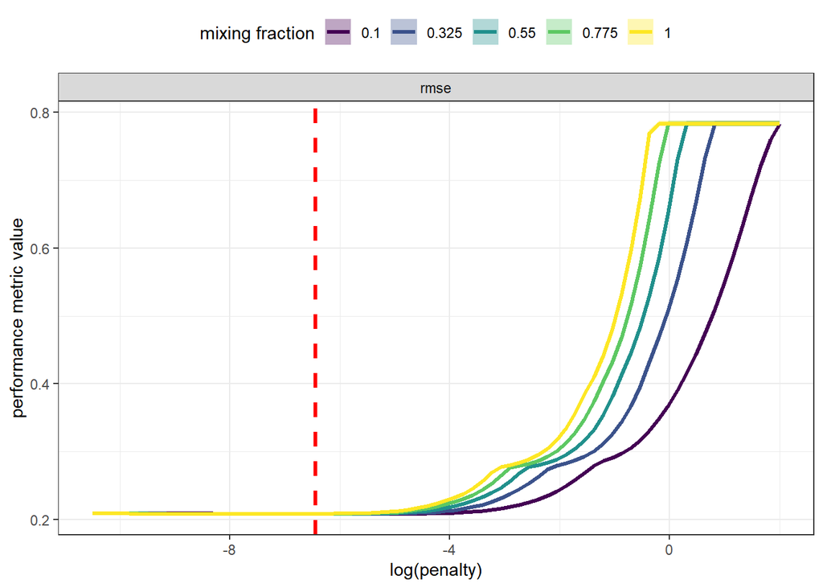

```r
enet_rsm3_res %>% collect_metrics() %>%
  filter(.metric %in% c("rmse")) %>%
  ggplot(mapping = aes(x = log(penalty))) +
  geom_ribbon(mapping = aes(ymin = mean - std_err,
                            ymax = mean + std_err,
                            group = interaction(mixture, .metric),
                            fill = as.factor(mixture)),
              alpha = 0.35) +
  geom_line(mapping = aes(y = mean,
                          group = interaction(mixture, .metric),
                          color = as.factor(mixture)),
            size = 1.15) +
  geom_vline(data = enet_rsm3_res %>% select_best(metric = 'rmse'),
             mapping = aes(xintercept = log(penalty)),
             color = 'red', linetype = 'dashed', size = 1.2) +
  facet_wrap(~.metric, scales = "free_y", ncol = 1) +
  scale_fill_viridis_d("mixing fraction") +
  scale_color_viridis_d("mixing fraction") +
  labs(y = 'performance metric value') +
  theme_bw() +
  theme(legend.position = "top")
```

Fit the rsm3 elastic net with the best tuning parameters:

```r
enet_rsm3_lowest_rmse_params <- enet_rsm3_res %>%
  select_best(metric = 'rmse') %>%
  select(all_of(names(enet_grid)))

final_enet_rsm3_wflow <- enet_rsm3_wflow %>%
  finalize_workflow(enet_rsm3_lowest_rmse_params)

final_enet_rsm3_fit <- final_enet_rsm3_wflow %>%
  fit_resamples(cv_folds,
                metrics = my_metrics)
final_enet_rsm3_fit %>% collect_metrics()
```

```
## # A tibble: 3 x 6
##   .metric .estimator  mean     n std_err .config
##   <chr>   <chr>      <dbl> <int>   <dbl> <chr>
## 1 mae     standard   0.163    25 0.00138 Preprocessor1_Model1
## 2 rmse    standard   0.208    25 0.00167 Preprocessor1_Model1
## 3 rsq     standard   0.929    25 0.00135 Preprocessor1_Model1
```

Add the result to all_cv_results:

```r
all_cv_results <- all_cv_results %>%
  bind_rows(enet_pairs_res %>% collect_metrics(summarize = FALSE) %>%
              mutate(wflow_id = "enet_pairs")) %>%
  bind_rows(enet_rsm3_res %>% collect_metrics(summarize = FALSE) %>%
              mutate(wflow_id = "enet_rsm3"))

all_cv_summaries <- all_cv_summaries %>%
  bind_rows(enet_pairs_res %>% collect_metrics(summarize = TRUE) %>%
              inner_join(enet_pairs_lowest_rmse_params %>%
                           mutate(keep_these = 'yes'),
                         by = names(enet_pairs_lowest_rmse_params)) %>%
              select(-keep_these) %>%
              mutate(wflow_id = "enet_pairs")) %>%
  bind_rows(enet_rsm3_res %>% collect_metrics(summarize = TRUE) %>%
              inner_join(enet_rsm3_lowest_rmse_params %>%
                           mutate(keep_these = 'yes'),
                         by = names(enet_rsm3_lowest_rmse_params)) %>%
              select(-keep_these) %>%
              mutate(wflow_id = "enet_rsm3"))
```

### Neural Network

Build neural network using mlp:

```r
nnet_spec <- mlp(hidden_units = tune(), penalty = tune(), epochs = 1000) %>%
  set_engine("nnet", MaxNWts = 2500, trace=FALSE) %>%
  set_mode("regression")
```

Define neural network workflow:

```r
nnet_wflow <- workflow() %>%
  add_model(nnet_spec) %>%
  add_recipe(bp_additive)
```

Tune the model using Bayesian optimization:

```r
nn_set <- parameters(nnet_wflow)


set.seed(2021)
nn_res <- nnet_wflow %>%
  tune_bayes(resamples = cv_folds,
             param_info = nn_set,
             initial = 5,
             iter = 10,
             metrics = my_metrics,
             control = control_bayes(no_improve = 30, verbose = TRUE))
```

```
## >  Generating a set of 5 initial parameter results
```

```
## √ Initialization complete
```

```
## Optimizing rmse using the expected improvement
```

```
## -- Iteration 1 -----------------------------------------------------------------
```

```
## i Current best:      rmse=0.1024 (@iter 0)
```

```
## i Gaussian process model
```

```
## √ Gaussian process model
```

```
## i Generating 5000 candidates
```

```
## i Predicted candidates
```

```
## i hidden_units=8, penalty=1.04e-10
```

```
## i Estimating performance
```

```
## √ Estimating performance
```

```
## (x) Newest results:  rmse=0.1195 (+/-0.00178)
```

```
## -- Iteration 2 -----------------------------------------------------------------
```

```
## i Current best:      rmse=0.1024 (@iter 0)
```

```
## i Gaussian process model
```

```
## √ Gaussian process model
```

```
## i Generating 5000 candidates
```

```
## i Predicted candidates
```

```
## i hidden_units=7, penalty=6.36e-05
```

```
## i Estimating performance
```

```
## √ Estimating performance
```

```
## (x) Newest results:  rmse=0.1225 (+/-0.00238)
```

```
## -- Iteration 3 -----------------------------------------------------------------
```

```
## i Current best:      rmse=0.1024 (@iter 0)
```

```
## i Gaussian process model
```

```
## √ Gaussian process model
```

```
## i Generating 5000 candidates
```

```
## i Predicted candidates
```

```
## i hidden_units=9, penalty=5.16e-05
```

```
## i Estimating performance
```

```
## √ Estimating performance
```

```
## (x) Newest results:  rmse=0.1186 (+/-0.00235)
```

```
## -- Iteration 4 -----------------------------------------------------------------
```

```
## i Current best:      rmse=0.1024 (@iter 0)
```

```
## i Gaussian process model
```

```
## √ Gaussian process model
```

```
## i Generating 5000 candidates
```

```
## i Predicted candidates
```

```
## i hidden_units=4, penalty=0.998
```

```
## i Estimating performance
```

```
## √ Estimating performance
```

```
## (x) Newest results:  rmse=0.1536 (+/-0.00226)
```

```
## -- Iteration 5 -----------------------------------------------------------------
```

```
## i Current best:      rmse=0.1024 (@iter 0)
```

```
## i Gaussian process model
```

```
## √ Gaussian process model
```

```
## i Generating 5000 candidates
```

```
## i Predicted candidates
```

```
## i hidden_units=8, penalty=3.1e-05
```

```
## i Estimating performance
```

```
## √ Estimating performance
```

```
## (x) Newest results:  rmse=0.1227 (+/-0.00395)
```

```
## -- Iteration 6 -----------------------------------------------------------------
```

```
## i Current best:      rmse=0.1024 (@iter 0)
```

```
## i Gaussian process model
```

```
## √ Gaussian process model
```

```
## i Generating 5000 candidates
```

```
## i Predicted candidates
```

```
## i hidden_units=10, penalty=0.0544
```

```
## i Estimating performance
```

```
## √ Estimating performance
```

```
## <3 Newest results:   rmse=0.1 (+/-0.000984)
```

```
## -- Iteration 7 -----------------------------------------------------------------
```

```
## i Current best:      rmse=0.1 (@iter 6)
```

```
## i Gaussian process model
```

```
## √ Gaussian process model
```

```
## i Generating 5000 candidates
```

```
## i Predicted candidates
```

```
## i hidden_units=9, penalty=0.0168
```

```
## i Estimating performance
```

```
## √ Estimating performance
```

```
## (x) Newest results:  rmse=0.1023 (+/-0.00108)
```

```
## -- Iteration 8 -----------------------------------------------------------------
```

```
## i Current best:      rmse=0.1 (@iter 6)
```

```
## i Gaussian process model
```

```
## √ Gaussian process model
```

```
## i Generating 5000 candidates
```

```
## i Predicted candidates
```

```
## i hidden_units=1, penalty=0.00274
```

```
## i Estimating performance
```

```
## √ Estimating performance
```

```
## (x) Newest results:  rmse=0.2475 (+/-0.00203)
```

```
## -- Iteration 9 -----------------------------------------------------------------
```

```
## i Current best:      rmse=0.1 (@iter 6)
```

```
## i Gaussian process model
```

```
## √ Gaussian process model
```

```
## i Generating 5000 candidates
```

```
## i Predicted candidates
```

```
## i hidden_units=5, penalty=1.05e-10
```

```
## i Estimating performance
```

```
## √ Estimating performance
```

```
## (x) Newest results:  rmse=0.1404 (+/-0.00654)
```

```
## -- Iteration 10 ----------------------------------------------------------------
```

```
## i Current best:      rmse=0.1 (@iter 6)
```

```
## i Gaussian process model
```

```
## √ Gaussian process model
```

```
## i Generating 5000 candidates
```

```
## i Predicted candidates
```

```
## i hidden_units=10, penalty=1e-10
```

```
## i Estimating performance
```

```
## √ Estimating performance
```

```
## (x) Newest results:  rmse=0.1196 (+/-0.00187)
```

Visualize the result:

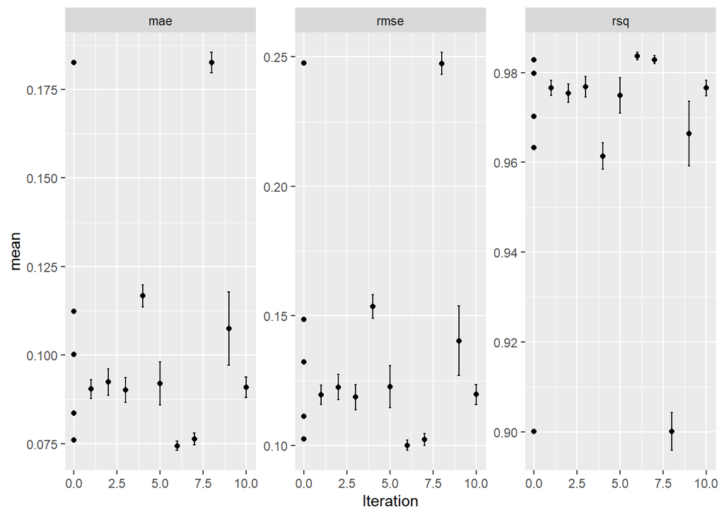

```r
autoplot(nn_res, type = "performance")
```

Find the best neural network model and fit on the train set:

```r
nn_lowest_rmse_params <- nn_res %>% select_best('rmse')

final_nn_wflow <- nnet_wflow %>%
  finalize_workflow(nn_lowest_rmse_params)

final_nn_fit <- final_nn_wflow %>%
  fit_resamples(cv_folds, metrics = my_metrics)
final_nn_fit %>% collect_metrics()
```

```
## # A tibble: 3 x 6
##   .metric .estimator   mean     n  std_err .config
##   <chr>   <chr>       <dbl> <int>    <dbl> <chr>
## 1 mae     standard   0.0743    25 0.000855 Preprocessor1_Model1
## 2 rmse    standard   0.0990    25 0.00127  Preprocessor1_Model1
## 3 rsq     standard   0.984     25 0.000490 Preprocessor1_Model1
```

```r
final_nn_model <- final_nn_wflow %>%  fit(ready_v_A)
```

Add the result to summary:

```r
all_cv_summaries <- all_cv_summaries %>%
  bind_rows(nn_res %>% collect_metrics(summarize = TRUE) %>%
              inner_join(nn_lowest_rmse_params %>%
                           mutate(keep_these = 'yes'),
                         by = names(nn_lowest_rmse_params)) %>%
              select(-keep_these) %>%
              mutate(wflow_id = "nnet"))

all_cv_results <- all_cv_results %>%
  bind_rows(nn_res %>% collect_metrics(summarize = FALSE) %>%
              inner_join(nn_lowest_rmse_params %>%
                           mutate(keep_these = 'yes'),
                         by = names(nn_lowest_rmse_params)) %>%
              select(-keep_these) %>%
              mutate(wflow_id = "nnet"))
```

### Random forest

Define the model and the workflow:

```r
rf_spec <- rand_forest(mtry = tune(), min_n = tune(), trees = 1000) %>%
  set_engine("ranger") %>%
  set_mode('regression')

rf_wflow <- workflow() %>%
  add_model(rf_spec) %>%
  add_formula(response ~ .)
```

Tune the model using Bayesian optimization:

```r
rf_set <-  rf_spec %>% parameters() %>% finalize(ready_v_A)

set.seed(2021)
rf_res <- rf_wflow %>%
  tune_bayes(resamples = cv_folds,
             param_info = rf_set,
             metrics = my_metrics,
             initial = 5,
             iter = 10,
             control = control_bayes(no_improve = 5, verbose = TRUE))
```

```
## >  Generating a set of 5 initial parameter results
```

```
## √ Initialization complete
```

```
## Optimizing rmse using the expected improvement
```

```
## -- Iteration 1 -----------------------------------------------------------------
```

```
## i Current best:      rmse=0.1401 (@iter 0)
```

```
## i Gaussian process model
```

```
## √ Gaussian process model
```

```
## i Generating 1551 candidates
```

```
## i Predicted candidates
```

```
## i mtry=16, min_n=18
```

```
## i Estimating performance
```

```
## √ Estimating performance
```

```
## <3 Newest results:   rmse=0.139 (+/-0.00168)
```

```
## -- Iteration 2 -----------------------------------------------------------------
```

```
## i Current best:      rmse=0.139 (@iter 1)
```

```
## i Gaussian process model
```

```
## √ Gaussian process model
```

```
## i Generating 1551 candidates
```

```
## i Predicted candidates
```

```
## i mtry=29, min_n=24
```

```
## i Estimating performance
```

```
## √ Estimating performance
```

```
## (x) Newest results:  rmse=0.1441 (+/-0.0019)
```

```
## -- Iteration 3 -----------------------------------------------------------------
```

```
## i Current best:      rmse=0.139 (@iter 1)
```

```
## i Gaussian process model
```

```
## √ Gaussian process model
```

```
## i Generating 1552 candidates
```

```
## i Predicted candidates
```

```
## i mtry=42, min_n=3
```

```
## i Estimating performance
```

```
## √ Estimating performance
```

```
## <3 Newest results:   rmse=0.1366 (+/-0.00184)
```

```
## -- Iteration 4 -----------------------------------------------------------------
```

```
## i Current best:      rmse=0.1366 (@iter 3)
```

```
## i Gaussian process model
```

```
## √ Gaussian process model
```

```
## i Generating 1541 candidates
```

```
## i Predicted candidates
```

```
## i mtry=13, min_n=40
```

```
## i Estimating performance
```

```
## √ Estimating performance
```

```
## (x) Newest results:  rmse=0.153 (+/-0.00165)
```

```
## -- Iteration 5 -----------------------------------------------------------------
```

```
## i Current best:      rmse=0.1366 (@iter 3)
```

```
## i Gaussian process model
```

```
## √ Gaussian process model
```

```
## i Generating 1549 candidates
```

```
## i Predicted candidates
```

```
## i mtry=14, min_n=2
```

```
## i Estimating performance
```

```
## √ Estimating performance
```

```
## <3 Newest results:   rmse=0.1343 (+/-0.00161)
```

```
## -- Iteration 6 -----------------------------------------------------------------
```

```
## i Current best:      rmse=0.1343 (@iter 5)
```

```
## i Gaussian process model
```

```
## √ Gaussian process model
```

```
## i Generating 1528 candidates
```

```
## i Predicted candidates
```

```
## i mtry=42, min_n=40
```

```
## i Estimating performance
```

```
## √ Estimating performance
```

```
## (x) Newest results:  rmse=0.1561 (+/-0.00203)
```

```
## -- Iteration 7 -----------------------------------------------------------------
```

```
## i Current best:      rmse=0.1343 (@iter 5)
```

```
## i Gaussian process model
```

```
## √ Gaussian process model
```

```
## i Generating 1536 candidates
```

```
## i Predicted candidates
```

```
## i mtry=37, min_n=2
```

```
## i Estimating performance
```

```
## √ Estimating performance
```

```
## (x) Newest results:  rmse=0.1366 (+/-0.00185)
```

```
## -- Iteration 8 -----------------------------------------------------------------
```

```
## i Current best:      rmse=0.1343 (@iter 5)
```

```
## i Gaussian process model
```

```
## √ Gaussian process model
```

```
## i Generating 1550 candidates
```

```
## i Predicted candidates
```

```
## i mtry=1, min_n=28
```

```
## i Estimating performance
```

```
## √ Estimating performance
```

```
## (x) Newest results:  rmse=0.3976 (+/-0.00213)
```

```
## -- Iteration 9 -----------------------------------------------------------------
```

```
## i Current best:      rmse=0.1343 (@iter 5)
```

```
## i Gaussian process model
```

```
## √ Gaussian process model
```

```
## i Generating 1547 candidates
```

```
## i Predicted candidates
```

```
## i mtry=42, min_n=22
```

```
## i Estimating performance
```

```
## √ Estimating performance
```

```
## (x) Newest results:  rmse=0.1441 (+/-0.0019)
```

```
## -- Iteration 10 ----------------------------------------------------------------
```

```
## i Current best:      rmse=0.1343 (@iter 5)
```

```
## i Gaussian process model
```

```
## √ Gaussian process model
```

```
## i Generating 1534 candidates
```

```
## i Predicted candidates
```

```
## i mtry=2, min_n=34
```

```
## i Estimating performance
```

```
## √ Estimating performance
```

```
## (x) Newest results:  rmse=0.2905 (+/-0.00156)
```

```
## ! No improvement for 5 iterations; returning current results.
```

Visualize the result:

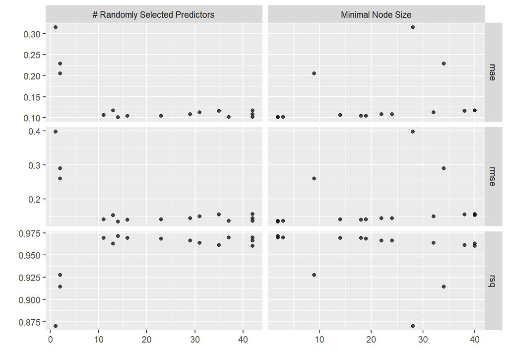

```r
rf_res %>% autoplot()
```

Find the best random forest model and fit on the train set:

```r
rf_lowest_rmse_params <- rf_res %>% select_best('rmse')

final_rf_spec <- rand_forest(mtry = rf_lowest_rmse_params$mtry,
                              min_n = rf_lowest_rmse_params$min_n,
                              trees = 1000) %>%
  set_engine('ranger', importance = 'impurity') %>%
  set_mode('regression')

final_rf_wflow <- workflow() %>%
  add_model(final_rf_spec) %>%
  add_formula(response ~ .)

set.seed(2021)
final_rf_model <-  final_rf_wflow %>%  fit(ready_v_A)
```

Add to summary:

```r
all_cv_summaries <- all_cv_summaries %>%
  bind_rows(rf_res %>% collect_metrics(summarize = TRUE) %>%
              inner_join(rf_lowest_rmse_params %>%
                           mutate(keep_these = 'yes'),
                         by = names(rf_lowest_rmse_params)) %>%
              select(-keep_these) %>%
              mutate(wflow_id = "rf"))

all_cv_results <- all_cv_results %>%
  bind_rows(rf_res %>% collect_metrics(summarize = FALSE) %>%
              inner_join(rf_lowest_rmse_params %>%
                           mutate(keep_these = 'yes'),
                         by = names(rf_lowest_rmse_params)) %>%
              select(-keep_these) %>%
              mutate(wflow_id = "rf"))
```

### Gradient boosted trees

Create gradient boosted trees:

```r
xgb_spec <- boost_tree(tree_depth = tune(), learn_rate = tune(),
                       trees = tune(), mtry = tune(), sample_size = tune()) %>%
  set_engine("xgboost") %>%
  set_mode("regression")
```

Define workflow:

```r
xgb_wflow <- workflow() %>%
  add_model(xgb_spec) %>%
  add_formula(response ~ .)
```

Tune gradient boosted trees using Bayesian optimization:

```r
xgb_set <- xgb_wflow %>% parameters() %>% finalize(ready_v_A)

set.seed(2021)
xgb_res <- xgb_wflow %>%
  tune_bayes(resamples = cv_folds,
             param_info = xgb_set,
             initial = 5,
             iter = 10,
             metrics = my_metrics,
             control = control_bayes(no_improve = 5, verbose = TRUE))
```

```
## ! There are 5 tuning parameters and 5 grid points were requested. This is
##   likely to cause numerical issues in the first few search iterations.
```

```
## >  Generating a set of 5 initial parameter results
```

```
## √ Initialization complete
```

```
## Optimizing rmse using the expected improvement
```

```
## -- Iteration 1 -----------------------------------------------------------------
```

```
## i Current best:      rmse=0.1182 (@iter 0)
```

```
## i Gaussian process model
```

```
## ! The Gaussian process model is being fit using 5 features but only has 5
##   data points to do so. This may cause errors or a poor model fit.
```

```
## √ Gaussian process model
```

```
## i Generating 5000 candidates
```

```
## i Predicted candidates
```

```
## i mtry=10, trees=1458, tree_depth=4, learn_rate=0.0883, sample_size=0.4
```

```
## i Estimating performance
```

```
## √ Estimating performance
```

```
## (x) Newest results:  rmse=0.1247 (+/-0.00149)
```

```
## -- Iteration 2 -----------------------------------------------------------------
```

```
## i Current best:      rmse=0.1182 (@iter 0)
```

```
## i Gaussian process model
```

```
## ! The Gaussian process model is being fit using 5 features but only has 6
##   data points to do so. This may cause errors or a poor model fit.
```

```
## √ Gaussian process model
```

```
## i Generating 5000 candidates
```

```
## i Predicted candidates
```

```
## i mtry=20, trees=35, tree_depth=14, learn_rate=0.0189, sample_size=0.677
```

```
## i Estimating performance
```

```
## √ Estimating performance
```

```
## (x) Newest results:  rmse=0.4992 (+/-0.00398)
```

```
## -- Iteration 3 -----------------------------------------------------------------
```

```
## i Current best:      rmse=0.1182 (@iter 0)
```

```
## i Gaussian process model
```

```
## √ Gaussian process model
```

```
## i Generating 5000 candidates
```

```
## i Predicted candidates
```

```
## i mtry=14, trees=1955, tree_depth=4, learn_rate=0.0216, sample_size=0.832
```

```
## i Estimating performance
```

```
## √ Estimating performance
```

```
## <3 Newest results:   rmse=0.1143 (+/-0.00134)
```

```
## -- Iteration 4 -----------------------------------------------------------------
```

```
## i Current best:      rmse=0.1143 (@iter 3)
```

```
## i Gaussian process model
```

```
## √ Gaussian process model
```

```
## i Generating 5000 candidates
```

```
## i Predicted candidates
```

```
## i mtry=18, trees=1521, tree_depth=2, learn_rate=0.0207, sample_size=0.573
```

```
## i Estimating performance
```

```
## √ Estimating performance
```

```
## (x) Newest results:  rmse=0.1461 (+/-0.00149)
```

```
## -- Iteration 5 -----------------------------------------------------------------
```

```
## i Current best:      rmse=0.1143 (@iter 3)
```

```
## i Gaussian process model
```

```
## √ Gaussian process model
```

```
## i Generating 5000 candidates
```

```
## i Predicted candidates
```

```
## i mtry=9, trees=1725, tree_depth=15, learn_rate=0.026, sample_size=0.199
```

```
## i Estimating performance
```

```
## √ Estimating performance
```

```
## (x) Newest results:  rmse=0.1233 (+/-0.00134)
```

```
## -- Iteration 6 -----------------------------------------------------------------
```

```
## i Current best:      rmse=0.1143 (@iter 3)
```

```
## i Gaussian process model
```

```
## √ Gaussian process model
```

```
## i Generating 5000 candidates
```

```
## i Predicted candidates
```

```
## i mtry=13, trees=1978, tree_depth=7, learn_rate=0.00499, sample_size=0.725
```

```
## i Estimating performance
```

```
## √ Estimating performance
```

```
## <3 Newest results:   rmse=0.1106 (+/-0.00136)
```

```
## -- Iteration 7 -----------------------------------------------------------------
```

```
## i Current best:      rmse=0.1106 (@iter 6)
```

```
## i Gaussian process model
```

```
## √ Gaussian process model
```

```
## i Generating 5000 candidates
```

```
## i Predicted candidates
```

```
## i mtry=32, trees=1911, tree_depth=2, learn_rate=0.0943, sample_size=0.946
```

```
## i Estimating performance
```

```
## √ Estimating performance
```

```
## (x) Newest results:  rmse=0.1372 (+/-0.00147)
```

```
## -- Iteration 8 -----------------------------------------------------------------
```

```
## i Current best:      rmse=0.1106 (@iter 6)
```

```
## i Gaussian process model
```

```
## √ Gaussian process model
```

```
## i Generating 5000 candidates
```

```
## i Predicted candidates
```

```
## i mtry=3, trees=1812, tree_depth=6, learn_rate=0.0931, sample_size=0.347
```

```
## i Estimating performance
```

```
## √ Estimating performance
```

```
## (x) Newest results:  rmse=0.164 (+/-0.0018)
```

```
## -- Iteration 9 -----------------------------------------------------------------
```

```
## i Current best:      rmse=0.1106 (@iter 6)
```

```
## i Gaussian process model
```

```
## √ Gaussian process model
```

```
## i Generating 5000 candidates
```

```
## i Predicted candidates
```

```
## i mtry=32, trees=1405, tree_depth=14, learn_rate=0.0899, sample_size=0.973
```

```
## i Estimating performance
```

```
## √ Estimating performance
```

```
## (x) Newest results:  rmse=0.1281 (+/-0.00155)
```

```
## -- Iteration 10 ----------------------------------------------------------------
```

```
## i Current best:      rmse=0.1106 (@iter 6)
```

```
## i Gaussian process model
```

```
## √ Gaussian process model
```

```
## i Generating 5000 candidates
```

```
## i Predicted candidates
```

```
## i mtry=41, trees=1791, tree_depth=9, learn_rate=0.00298, sample_size=0.646
```

```
## i Estimating performance
```

```
## √ Estimating performance
```

```
## (x) Newest results:  rmse=0.1163 (+/-0.00145)
```

Visualize the result:

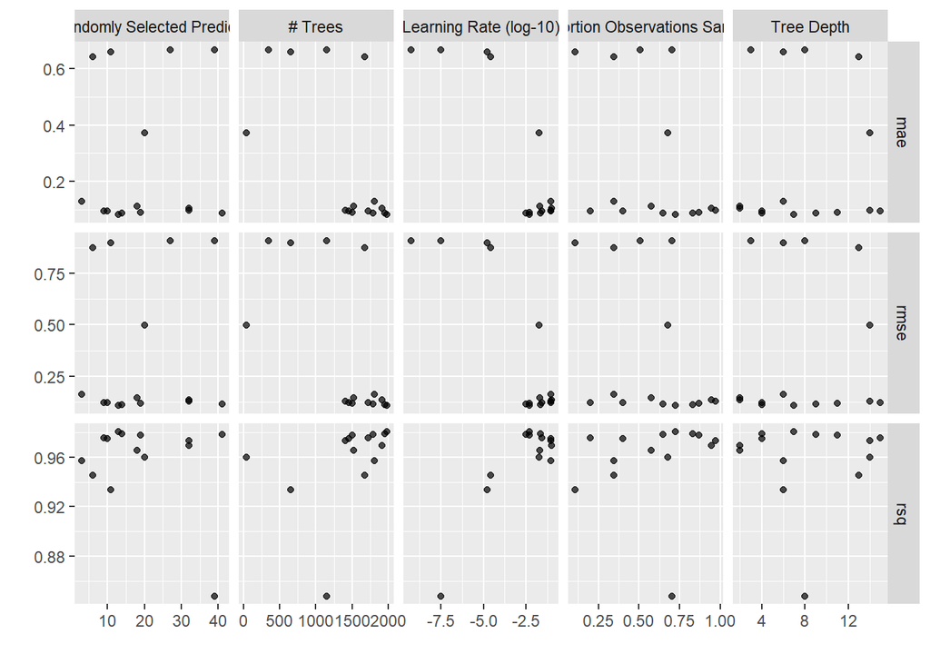

```r
xgb_res %>% autoplot()
```

Find the best gradient boosted trees model and fit on the train set:

```r
xgb_lowest_rmse_params <- xgb_res %>% select_best('rmse')

final_xgb_wflow <- xgb_wflow %>%
  finalize_workflow(xgb_lowest_rmse_params)

set.seed(2021)
final_xgb_fit <- final_xgb_wflow %>%
  fit_resamples(cv_folds, metrics = my_metrics)
final_xgb_fit %>% collect_metrics()
```

```
## # A tibble: 3 x 6
##   .metric .estimator   mean     n  std_err .config
##   <chr>   <chr>       <dbl> <int>    <dbl> <chr>
## 1 mae     standard   0.0820    25 0.000846 Preprocessor1_Model1
## 2 rmse    standard   0.111     25 0.00139  Preprocessor1_Model1
## 3 rsq     standard   0.980     25 0.000603 Preprocessor1_Model1
```

```r
final_xgb_model <- final_xgb_wflow %>% fit(ready_v_A)
```

Add to summary:

```r
all_cv_summaries <- all_cv_summaries %>%
  bind_rows(xgb_res %>% collect_metrics(summarize = TRUE) %>%
              inner_join(xgb_lowest_rmse_params %>%
                           mutate(keep_these = 'yes'),
                         by = names(xgb_lowest_rmse_params)) %>%
              select(-keep_these) %>%
              mutate(wflow_id = "xgb"))

all_cv_results <- all_cv_results %>%
  bind_rows(xgb_res %>% collect_metrics(summarize = FALSE) %>%
              inner_join(xgb_lowest_rmse_params %>%
                           mutate(keep_these = 'yes'),
                         by = names(xgb_lowest_rmse_params)) %>%
              select(-keep_these) %>%
              mutate(wflow_id = "xgb"))
```

### Support Vector Machine (SVM)

Define SVM model and workflow:

```r
svm_rbf_spec <- svm_rbf(cost = tune(), rbf_sigma = tune(), margin = tune()) %>%
  set_engine("kernlab") %>%
  set_mode("regression")

svm_rbf_wflow <- workflow() %>%
  add_model(svm_rbf_spec) %>%
  add_recipe(bp_additive)
```

Tune SVM using racing with ANOVA:

```r
rbf_grid <- crossing(rbf_sigma = c(0.01, 0.05, 0.1, 0.2, 0.4, 0.8, 1.25, 1.5),
                     cost = c(0.01, 0.1, 1, 10, 100, 1000),
                     margin = c(0.01, 0.05, 0.1, 1.0))

#set.seed(2021)
#svm_rbf_res <- tune_grid(
#  svm_rbf_wflow,
#  resamples = cv_folds,
#  grid = rbf_grid,
#  metrics = my_metrics
#)

set.seed(2021)
svm_rbf_res <- tune_race_anova(
  svm_rbf_wflow,
  resamples = cv_folds,
  grid = rbf_grid,
  metrics = my_metrics
)
```

Visualize the result:

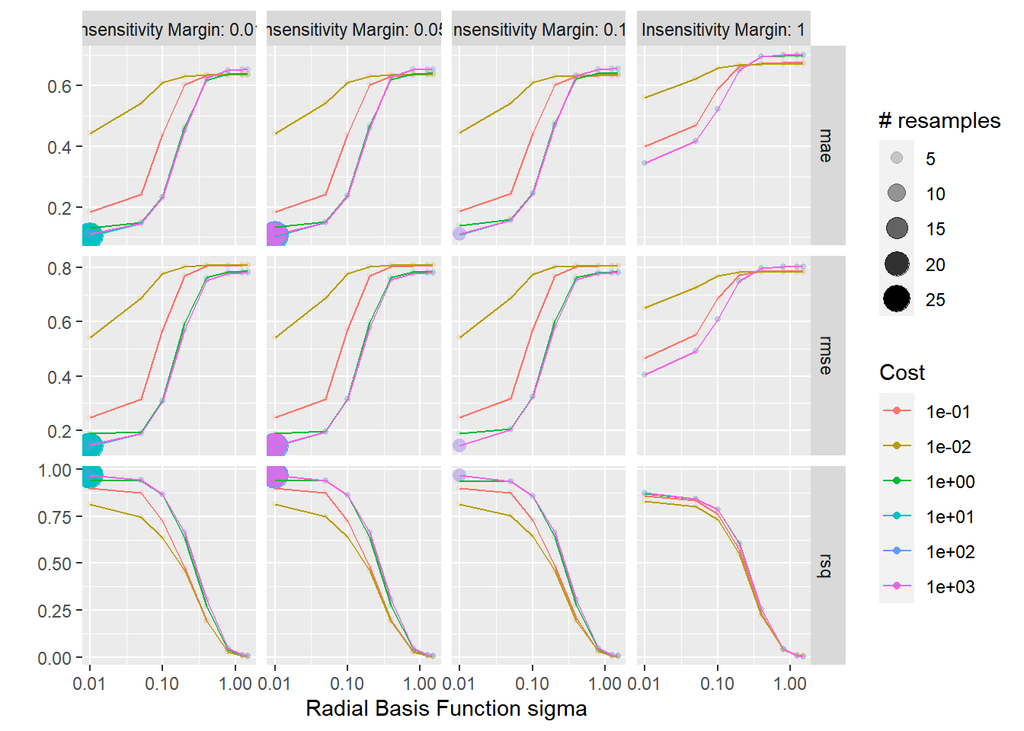

```r
svm_rbf_res %>% autoplot()
```

Identify the best tuning parameters and fit the final model:

```r
svm_lowest_rmse_params <- svm_rbf_res %>% select_best('rmse')

final_svm_rbf_wflow  <- svm_rbf_wflow  %>%
  finalize_workflow(svm_lowest_rmse_params)

set.seed(2021)
final_svm_fit <- final_svm_rbf_wflow %>%
  fit_resamples(cv_folds,
                metrics = my_metrics)
final_svm_fit %>% collect_metrics()
```

```
## # A tibble: 3 x 6
##   .metric .estimator  mean     n  std_err .config
##   <chr>   <chr>      <dbl> <int>    <dbl> <chr>
## 1 mae     standard   0.104    25 0.000645 Preprocessor1_Model1
## 2 rmse    standard   0.141    25 0.00122  Preprocessor1_Model1
## 3 rsq     standard   0.968    25 0.000710 Preprocessor1_Model1
```

Add to summary:

```r
all_cv_summaries <- all_cv_summaries %>%
  bind_rows(svm_rbf_res %>% collect_metrics(summarize = TRUE) %>%
              inner_join(svm_lowest_rmse_params %>%
                           mutate(keep_these = 'yes'),
                         by = names(svm_lowest_rmse_params)) %>%
              select(-keep_these) %>%
              mutate(wflow_id = "svm rbf"))

all_cv_results <- all_cv_results %>%
  bind_rows(svm_rbf_res %>% collect_metrics(summarize = FALSE) %>%
              inner_join(svm_lowest_rmse_params %>%
                           mutate(keep_these = 'yes'),
                         by = names(svm_lowest_rmse_params)) %>%
              select(-keep_these) %>%
              mutate(wflow_id = "svm rbf"))
```

### K-nearest neighbors

Create model and workflow:

```r
knn_spec <- nearest_neighbor(neighbors = tune(), weight_func = tune()) %>%
  set_mode("regression") %>%
  set_engine("kknn")

knn_wflow <- workflow() %>%
  add_model(knn_spec) %>%
  add_formula(response ~ .)
```

Tune KNN using racing with ANOVA:

```r
knn_grid <- crossing(neighbors = seq(1,30),
                     weight_func = c("rectangular", "triangular", "epanechnikov", "biweight", "triweight", "cos", "inv", "gaussian", "rank", "optimal"))

set.seed(2021)
knn_res <- tune_race_anova(
  knn_wflow,
  resamples = cv_folds,
  grid = knn_grid,
  metrics = my_metrics
)
```

Visualize the result:

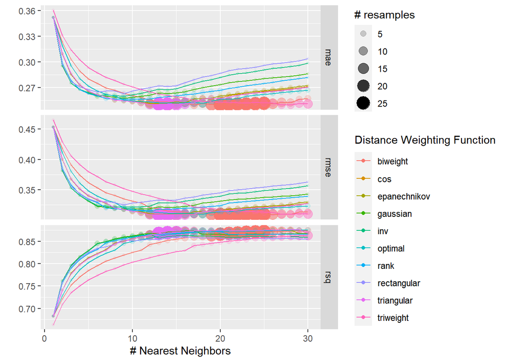

```r
knn_res %>% autoplot()
```

Identify the best tuning parameters and fit the final model:

```r
knn_lowest_rmse_params <- knn_res %>% select_best('rmse')

final_knn_wflow  <- knn_wflow  %>%
  finalize_workflow(knn_lowest_rmse_params)

set.seed(2021)
final_knn_fit <- final_knn_wflow %>%
  fit_resamples(cv_folds,
                metrics = my_metrics)
final_knn_fit %>% collect_metrics()
```

```
## # A tibble: 3 x 6
##   .metric .estimator  mean     n std_err .config
##   <chr>   <chr>      <dbl> <int>   <dbl> <chr>
## 1 mae     standard   0.250    25 0.00154 Preprocessor1_Model1
## 2 rmse    standard   0.309    25 0.00177 Preprocessor1_Model1
## 3 rsq     standard   0.868    25 0.00283 Preprocessor1_Model1
```

```r
knn_lowest_rmse_params
```

```
## # A tibble: 1 x 3
##   neighbors weight_func .config
##       <int> <chr>       <chr>
## 1        22 biweight    Preprocessor1_Model022
```

Add to summary:

```r
all_cv_summaries <- all_cv_summaries %>%
  bind_rows(knn_res %>% collect_metrics(summarize = TRUE) %>%
              inner_join(knn_lowest_rmse_params %>%
                           mutate(keep_these = 'yes'),
                         by = names(knn_lowest_rmse_params)) %>%
              select(-keep_these) %>%
              mutate(wflow_id = "knn rbf"))

all_cv_results <- all_cv_results %>%
  bind_rows(knn_res %>% collect_metrics(summarize = FALSE) %>%
              inner_join(knn_lowest_rmse_params %>%
                           mutate(keep_these = 'yes'),
                         by = names(knn_lowest_rmse_params)) %>%
              select(-keep_these) %>%
              mutate(wflow_id = "knn rbf"))
```

### Model comparison

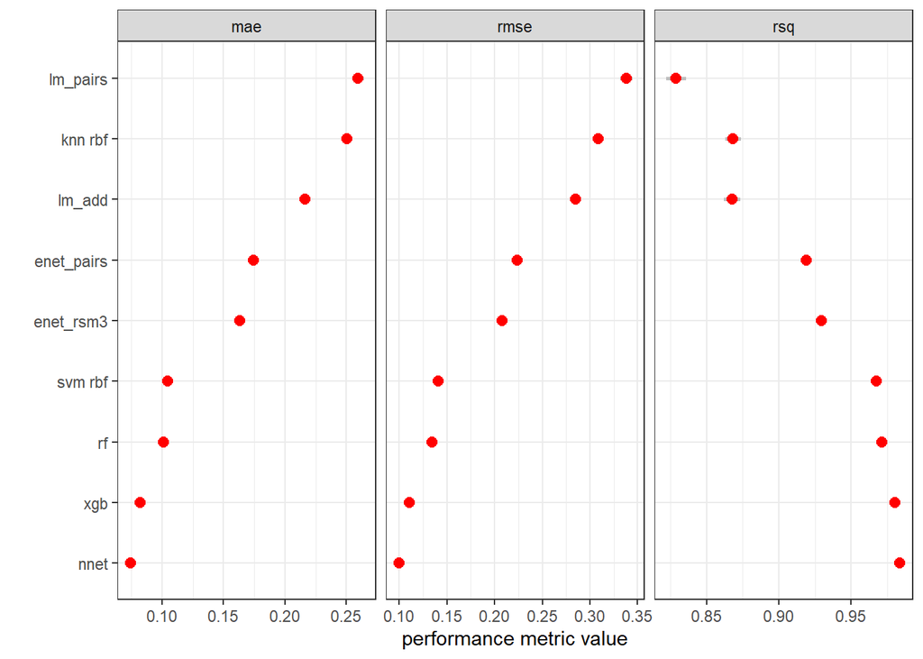

```r
all_cv_summaries %>%
  mutate(wflow_id = forcats::fct_reorder(wflow_id, mean, min)) %>%
  ggplot(mapping = aes(x = wflow_id)) +
  geom_linerange(mapping = aes(ymin = mean - 2*std_err,
                               ymax = mean + 2*std_err,
                               group = interaction(.metric, wflow_id)),
                 color = 'grey', size = 1.) +
  geom_linerange(mapping = aes(ymin = mean - 1*std_err,
                               ymax = mean + 1*std_err,
                               group = interaction(.metric, wflow_id)),
                 color = 'red', size = 1.2) +
  geom_point(mapping = aes(y = mean),
             color = 'red', size = 2.5) +
  coord_flip() +
  facet_wrap(~.metric, scales = "free_x") +
  labs(y = "performance metric value", x ="") +
  theme_bw()
```

From the plot we can see the neural network model performs the best base on MAE, RMSE and R-Squared. The gradient boosted tree is the second, but result is very close.

Save the best model:

```r
final_nn_model %>% readr::write_rds("neural_network_regression_v.rds")
final_xgb_model %>% readr::write_rds("xgb_regression_v.rds")
```